# Relationship Between Dominant Hand and Grip Strength in Young Adults

Julia Curry, Yunshu Qiu, Weihang Huang, Nicole Wei, Binghao Deng

2023-12-12

## Introduction

The knowledge of how changes in body angle and dominant hand use affect the strength of the grip can be used to design environments and tools to maximize biomechanical abilities for both everyday use and hand rehabitation program.

## Methods

In order to assess the effect of dominant versus non-dominant hand grip strength, the force data for 8 different angle positions were measured and the results were analysed for dominant hand and non-dominant hand. Our data consisted of 16 data files for each of the 10 Boston college students whose dominant hand are all right hand (160 data files in total). In order to obtain data, we designed and constructed a portable Arduino-based force-data acquisition system (DAQ).

1. DAQ Design components

100-kg S-type Load cell with HX711 amplifier

Arduino Uno microcontroller

2. Angle Measurement Setup

a ganiometer was constructed. Then, found the center of the elbow joint in lateral view and marked this position with a marker. From that point, we marked a line along the lateral margin of the radius. We then poked a hole through the center of the ganiometer to affix it to the upper arm so that the center aligns with the mark at the elbow and the 0-180angle axis aligns with the long axis of the humerus. The wrist was completely aligned with the forearm to prevent any force exerted from the wrist. This arm position allows for complete isolation of the hand for more accurate measurement of the grip strength.

3. Data Collection

Then, in order to use the ganiometer to collect data from 8 arm angles. We tested grip strength at the angles of 22.5, 45, 67.5, 90, 112.5, 135, 157.5, and 180 degrees. We moved through the 8 arm angles by rotating our arms about the elbow in increasing angles for both dominant and nondominant hands. For each angle measurement, the participants used a soft cloth to wrap the “S” shaped load cell metal block and squeezed the top and bottom for 10 seconds to ensure max values for each angle, with the palm facing forward. While squeezing, the palm is always facing up and the wrist angle is always 180 degrees for each measurement. Each participant rested for 1-2 minutes in between grip strength measurement.

## Results

We first calculated the normalized force by dividing each force value by the maximum force value measured in that hand. As shown in the Figure 1 below, we plotted the normalized force of dominant hand (red) and non-dominant hand (blue) over the range of 8 carrying angles spanning from 22.5 degree to 180 degree.

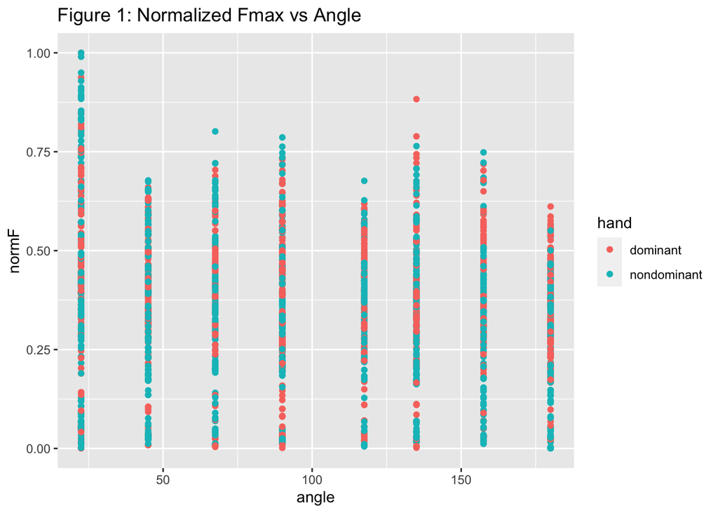

Next, we calculated the mean of normalized force for each hand at each carrying angle and plotted in the Figure 2 below. Spearman test was used to determine the correlation between angle and grip strength.

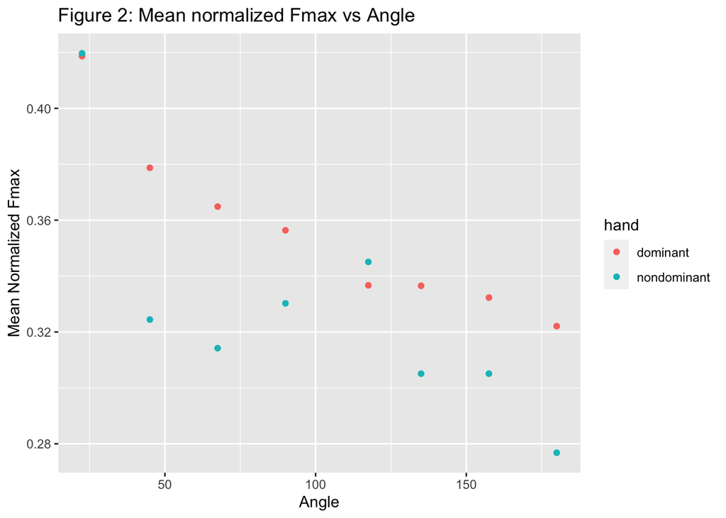

```
##
##  Spearman's rank correlation rho
##
## data:  dat_norm_mean$angle and dat_norm_mean$Fmax_norm_mean
## S = 1154.8, p-value = 0.002627
## alternative hypothesis: true rho is not equal to 0
## sample estimates:
##        rho
## -0.6982371
```

Then we generated three different models (second order, third order, and fourth order) and calculated their AICs values in Table 1 below.

Table 1: AIC values for 2nd, 3rd, and 4th order models

| who | hand | model | AICc |
| --- | --- | --- | --- |
| Calvin | dominant | m2 | -182.225834 |
| Calvin | dominant | m3 | -186.900126 |
| Calvin | dominant | m4 | -199.056148 |
| Calvin | nondominant | m2 | -175.248947 |
| Calvin | nondominant | m3 | -173.654580 |
| Calvin | nondominant | m4 | -190.900874 |
| Julia | dominant | m2 | -216.284147 |
| Julia | dominant | m3 | -215.421256 |
| Julia | dominant | m4 | -215.355851 |
| Julia | nondominant | m2 | -259.208409 |
| Julia | nondominant | m3 | -263.129552 |
| Julia | nondominant | m4 | -261.927782 |
| Peter | dominant | m2 | -27.881384 |
| Peter | dominant | m3 | -25.738425 |
| Peter | dominant | m4 | -23.542617 |
| Peter | nondominant | m2 | -5.642926 |
| Peter | nondominant | m3 | -4.360909 |
| Peter | nondominant | m4 | -2.451992 |
| Will | dominant | m2 | -101.488683 |
| Will | dominant | m3 | -99.468701 |
| Will | dominant | m4 | -97.268794 |
| Will | nondominant | m2 | -53.072825 |
| Will | nondominant | m3 | -51.576118 |
| Will | nondominant | m4 | -53.735566 |
| amy | dominant | m2 | -169.676914 |
| amy | dominant | m3 | -167.483424 |
| amy | dominant | m4 | -165.236998 |
| amy | nondominant | m2 | -272.923358 |
| amy | nondominant | m3 | -270.951313 |
| amy | nondominant | m4 | -268.639113 |
| chris | dominant | m2 | -205.048980 |
| chris | dominant | m3 | -204.811403 |
| chris | dominant | m4 | -216.993336 |
| chris | nondominant | m2 | -145.270983 |
| chris | nondominant | m3 | -180.747861 |
| chris | nondominant | m4 | -184.122019 |
| leo | dominant | m2 | 16.217141 |
| leo | dominant | m3 | 18.250154 |
| leo | dominant | m4 | 20.519292 |
| leo | nondominant | m2 | 11.961376 |
| leo | nondominant | m3 | 7.950991 |
| leo | nondominant | m4 | 9.977207 |
| nicole | dominant | m2 | -221.061288 |
| nicole | dominant | m3 | -219.223926 |
| nicole | dominant | m4 | -217.833070 |
| nicole | nondominant | m2 | -263.682998 |
| nicole | nondominant | m3 | -267.103645 |
| nicole | nondominant | m4 | -265.919412 |
| roy | dominant | m2 | -148.466828 |
| roy | dominant | m3 | -150.418193 |
| roy | dominant | m4 | -187.680504 |
| roy | nondominant | m2 | -221.314693 |
| roy | nondominant | m3 | -221.951899 |
| roy | nondominant | m4 | -219.652980 |
| ryan | dominant | m2 | -111.750639 |
| ryan | dominant | m3 | -110.251006 |
| ryan | dominant | m4 | -109.820102 |
| ryan | nondominant | m2 | -206.698604 |
| ryan | nondominant | m3 | -204.519401 |
| ryan | nondominant | m4 | -209.294232 |

Next, using the best fit model with the smallest AIC value, we predicted the angle at which normalized force is maximized (theta max) for each hand listed them in Table 2 below

Table 2: Best fitting model due to lowest AICc value and predicted theta max

| who | hand | model | theta_max | AICc |
| --- | --- | --- | --- | --- |
| Calvin | dominant | m4 | 22.50000 | -199.056148 |
| Calvin | nondominant | m4 | 22.50000 | -190.900874 |
| Julia | dominant | m2 | 22.50000 | -216.284147 |
| Julia | nondominant | m3 | 22.50000 | -263.129552 |
| Peter | dominant | m2 | 22.50000 | -27.881384 |
| Peter | nondominant | m2 | 22.50000 | -5.642926 |
| Will | dominant | m2 | 180.00000 | -101.488683 |
| Will | nondominant | m4 | 106.68919 | -53.735566 |
| amy | dominant | m2 | 110.31532 | -169.676914 |
| amy | nondominant | m2 | 180.00000 | -272.923358 |
| chris | dominant | m4 | 156.82432 | -216.993336 |
| chris | nondominant | m4 | 22.50000 | -184.122019 |
| leo | dominant | m2 | 22.50000 | 16.217141 |
| leo | nondominant | m3 | 22.50000 | 7.950991 |
| nicole | dominant | m2 | 22.50000 | -221.061288 |
| nicole | nondominant | m3 | 22.50000 | -267.103645 |
| roy | dominant | m4 | 22.50000 | -187.680504 |
| roy | nondominant | m3 | 22.50000 | -221.951899 |
| ryan | dominant | m2 | 22.50000 | -111.750639 |
| ryan | nondominant | m4 | 32.27477 | -209.294232 |

Finally, we want to know if there is a shift in theta max between dominant hand and non-dominant hand. We calculated the mean and standard error of the shift in theta max below, and the resulting p-value from an ANOVA test of the shift is 0.6307. This result was visualized in Figure 3 where we compared the theta max of dominant and non-dominant hands for each person.

```
## Analysis of Variance Table
##
## Response: theta_max
##           Df Sum Sq Mean Sq F value Pr(>F)
## hand       1    821   821.5  0.2392 0.6307
## Residuals 18  61814  3434.1
```

Table 3: Mean shift in theta max

| mean.shift | se.shift |
| --- | --- |
| -12.81757 | 17.23243 |

[figure not shown]

## Discussion

The Spearman correlation showed a p value of 0.002627, which is <0.05. As a result, this indicates that there is a significant negative correlation between elbow angles and grip strength. As the elbow angle decreases, the grip strength increases. The smallest angle correlates with the highest Fmax, thus the greatest grip strength. To assess whether there is a difference between the grip strength and the dominant/nondominant hand, the mean shift of -12.82 shows a p value of <0.6307. This indicates that there is no significance between the effect of dominant and nondominant hand on grip strength, despite a seemingly weaker nondominant hand showed in figure 2. Collectively, the data showed a significant negative correlation between elbow angle and grip strength, regardless of dominant or nondominant hand usage.

In Nayak, Kumar, and Oraon (2023), the researchers measured the correlation between carrying angle (the angle between the forearm and the upper arm) and grip strength among the 203 participants with a mean age of 22.95 ± 2.11. The results showed a weak negative correlation between carrying angle and grip strength on the left side, but no significant correlation on the right side. Our data confirms the negative correlation between angle and grip strength, but does not support the effect of hand dominance on grip strength. This may be a result of small sample size, as this stusy only has 10 participants, compare to the large participant pool in the Nayak study. To verify the result further in the future, a bigger sample size is needed for a holistic review on the study.

This study on the grip strength measurement gives insights into the overall strength and function of the forearm and hand muscles, which are crucial assessments for hand rehabilitation programs. Specifically, for the population age 20-22. This study provides a quantified methods and indication for the assessment of rehabilitation progress for the adolescent population.

For future plan, we intend to measure the sex or hand size or grip position’s effect on the grip strength to obtain a better and more comprehensive insight into the rehabilitation progress for the adolescent population.

## Author Contributions

Julia Curry: Helped set up Arduino unit, Created Skeleton of project report, Wrote Methods.

Yunshu Qiu: Completed all the codes for data analysis in the result section and helped set up the Arduino unit for data collection.

Nicole Wei: Completed introduction and discussion section. Edited the code for better understanding.

Binghao Deng: Polished materials and methods, and edited the overall writing

Weihang Huang: Organized additional participants for data collection and aided in code writing.

# References

Nayak, Subhasmita, Pravin Kumar, and Anil Kumar Oraon. 2023. “Relationship of Carrying Angle with Grip Strength and Anthropometric Measurements in Young Adults.” *Bulletin of Faculty of Physical Therapy* 28 (1): 1–8.

Richards, Lorie Gage, Bonni Olson, and Pamela Palmiter-Thomas. 1996. “How Forearm Position Affects Grip Strength.” *The American Journal of Occupational Therapy* 50 (2): 133–38.